# Part I - Exploratory Analysis of U.S. Flight Delays (2011-2020)

## Introduction

In this project, I will explore data from the U.S. Department of Transportation Reporting Carrier On-Time Performance Dataset, which contains detailed flight records including dates, airlines, routes, delays, cancellations, and distance traveled. To make the dataset more manageable for analysis, I focused on the most recent 10 years available in the sample (2011–2020), resulting in a subset of approximately ~596,000 flights.

The goal of this exploratory analysis is to investigate flight behavior, delays, and airline performance using visualization. My questions will guide the visual approach and help identify trends and relationships in domestic U.S. air travel.

## Preliminary Wrangling

```python
# import all packages and set plots to be embedded inline
import numpy as np
import pandas as pd
import matplotlib.pyplot as plt
import seaborn as sns

sns.set(style="whitegrid")  # clean plot style
%matplotlib inline
```

```python
# Helper plotting functions to avoid repetitive code

def plot_hist(df, column, bins=50, title=None, xlabel=None, figsize=(8,5)):
    """Generic histogram helper."""
    plt.figure(figsize=figsize)
    plt.hist(df[column].dropna(), bins=bins)
    plt.title(title if title else f"Distribution of {column}")
    plt.xlabel(xlabel if xlabel else column)
    plt.ylabel("Count")
    plt.show()


def plot_count(df, column, order=None, title=None, xlabel=None, rotation=0, figsize=(8,5)):
    """Generic count plot / bar chart for categorical variables."""
    plt.figure(figsize=figsize)
    sns.countplot(data=df, x=column, order=order)
    plt.title(title if title else f"{column} counts")
    plt.xlabel(xlabel if xlabel else column)
    plt.ylabel("Count")
    plt.xticks(rotation=rotation)
    plt.show()


def plot_scatter(df, x, y, alpha=0.3, title=None, xlabel=None, ylabel=None, figsize=(8,6)):
    """Generic scatter plot helper."""
    plt.figure(figsize=figsize)
    plt.scatter(df[x], df[y], alpha=alpha)
    plt.title(title if title else f"{y} vs {x}")
    plt.xlabel(xlabel if xlabel else x)
    plt.ylabel(ylabel if ylabel else y)
    plt.show()


def plot_box(df, x, y, order=None, title=None, xlabel=None, ylabel=None, figsize=(8,6)):
    """Generic boxplot helper."""
    plt.figure(figsize=figsize)
    sns.boxplot(data=df, x=x, y=y, order=order)
    plt.title(title if title else f"{y} by {x}")
    plt.xlabel(xlabel if xlabel else x)
    plt.ylabel(ylabel if ylabel else y)
    plt.show()


def plot_heatmap_from_df(df, cols, title="Correlation heatmap", figsize=(10,8), annot=True):
    """Correlation heatmap helper from list of columns."""
    plt.figure(figsize=figsize)
    corr = df[cols].corr()
    sns.heatmap(corr, annot=annot, cmap="coolwarm", fmt=".2f")
    plt.title(title)
    plt.show()


def facet_hist(df, column, facet_col, bins=30, col_wrap=4,
               title=None, xlabel=None, sharex=True, sharey=True):
    """FacetGrid histogram helper."""
    g = sns.FacetGrid(df, col=facet_col, col_wrap=col_wrap, sharex=sharex, sharey=sharey)
    g.map(plt.hist, column, bins=bins)
    g.set_axis_labels(xlabel if xlabel else column, "Count")
    if title:
        plt.subplots_adjust(top=0.85)
        g.fig.suptitle(title)
    plt.show()


def scatter_with_hue(df, x, y, hue, alpha=0.3, title=None,
                     xlabel=None, ylabel=None, figsize=(8,6)):
    """Scatter plot with color encoding."""
    plt.figure(figsize=figsize)
    sns.scatterplot(data=df, x=x, y=y, hue=hue, alpha=alpha)
    plt.title(title if title else f"{y} vs {x} by {hue}")
    plt.xlabel(xlabel if xlabel else x)
    plt.ylabel(ylabel if ylabel else y)
    plt.legend()
    plt.show()


def plot_pivot_heatmap(df, values, index, aggfunc="mean",
                       cmap="coolwarm", fmt=".1f",
                       title=None, xlabel=None, ylabel=None,
                       figsize=(8,6)):
    """
    Create a heatmap from a pivot table.
    """
    pivot = df.pivot_table(values=values, index=index, aggfunc=aggfunc)

    plt.figure(figsize=figsize)
    sns.heatmap(pivot, annot=True, cmap=cmap, fmt=fmt)
    plt.title(title if title else f"{aggfunc} {values} by {index}")
    plt.xlabel(xlabel if xlabel else values)
    plt.ylabel(ylabel if ylabel else index)
    plt.show()


def facet_boxplot(df, facet_col, x, y, top_n=None, order=None,
                  col_wrap=3, height=4, sharey=False,
                  title=None, xlabel=None, ylabel=None,
                  rotate_xticks=0, dropna_cols=None):
    """
    Faceted boxplot helper.
    Optionally limits facets to top_n most frequent categories in facet_col.
    """
    data = df.copy()

    # Optional NA handling for the specific columns used
    if dropna_cols:
        data = data.dropna(subset=dropna_cols)

    # Optionally restrict to top N facet categories
    if top_n is not None:
        top_vals = data[facet_col].value_counts().index[:top_n]
        data = data[data[facet_col].isin(top_vals)]

    g = sns.FacetGrid(data, col=facet_col, col_wrap=col_wrap, height=height, sharey=sharey)

    # Use a mapped function so it works within FacetGrid
    def _boxplot(data, color=None, **kws):
        sns.boxplot(data=data, x=x, y=y, order=order)

    g.map_dataframe(_boxplot)

    # Labels
    g.set_axis_labels(xlabel if xlabel else x, ylabel if ylabel else y)

    # Rotate ticks if needed
    for ax in g.axes.flatten():
        for tick in ax.get_xticklabels():
            tick.set_rotation(rotate_xticks)

    # Title
    if title:
        plt.subplots_adjust(top=0.85)
        g.fig.suptitle(title)

    plt.show()
```

```python
# Load dataset (raw)
# Note: dataset is large. Using low_memory=False to prevent type inference issues.

df = pd.read_csv("airline_2m.csv", encoding="latin1", low_memory=False)

df.head()
```

|  | Year | Quarter | Month | DayofMonth | DayOfWeek | FlightDate | Reporting_Airline | DOT_ID_Reporting_Airline | IATA_CODE_Reporting_Airline | Tail_Number | ... | Div4WheelsOff | Div4TailNum | Div5Airport | Div5AirportID | Div5AirportSeqID | Div5WheelsOn | Div5TotalGTime | Div5LongestGTime | Div5WheelsOff | Div5TailNum |
| --- | --- | --- | --- | --- | --- | --- | --- | --- | --- | --- | --- | --- | --- | --- | --- | --- | --- | --- | --- | --- | --- |
| 0 | 1998 | 1 | 1 | 2 | 5 | 1998-01-02 | NW | 19386 | NW | N297US | ... | NaN | NaN | NaN | NaN | NaN | NaN | NaN | NaN | NaN | NaN |
| 1 | 2009 | 2 | 5 | 28 | 4 | 2009-05-28 | FL | 20437 | FL | N946AT | ... | NaN | NaN | NaN | NaN | NaN | NaN | NaN | NaN | NaN | NaN |
| 2 | 2013 | 2 | 6 | 29 | 6 | 2013-06-29 | MQ | 20398 | MQ | N665MQ | ... | NaN | NaN | NaN | NaN | NaN | NaN | NaN | NaN | NaN | NaN |
| 3 | 2010 | 3 | 8 | 31 | 2 | 2010-08-31 | DL | 19790 | DL | N6705Y | ... | NaN | NaN | NaN | NaN | NaN | NaN | NaN | NaN | NaN | NaN |
| 4 | 2006 | 1 | 1 | 15 | 7 | 2006-01-15 | US | 20355 | US | N504AU | ... | NaN | NaN | NaN | NaN | NaN | NaN | NaN | NaN | NaN | NaN |

5 rows × 109 columns

```python
# Keep only the last 10 years in the dataset
max_year = df['Year'].max()
start_year = max_year - 9

print("Most recent year:", max_year)
print("Keeping years from", start_year, "to", max_year)

df_10yr = df[df['Year'].between(start_year, max_year)].copy()

# Quick check
df_10yr['Year'].value_counts().sort_index()
```

```
Most recent year: 2020
Keeping years from 2011 to 2020
```

```
Year
2011    62672
2012    62813
2013    65957
2014    59668
2015    59876
2016    57729
2017    58361
2018    74175
2019    76616
2020    18905
Name: count, dtype: int64
```

```python
# Candidate columns that are relevant
cols_wanted = [
    'Year','Quarter','Month','DayofMonth','DayOfWeek','FlightDate',
    'Reporting_Airline','Origin','Dest',
    'CRSDepTime','DepTime','DepDelay',
    'CRSArrTime','ArrTime','ArrDelay',
    'Cancelled','CancellationCode','Diverted',
    'Distance','AirTime'
]

# Keep only columns that exist (avoids errors)
cols_present = [c for c in cols_wanted if c in df_10yr.columns]
print("Columns kept:", cols_present)

flights = df_10yr[cols_present].copy()
flights.head()
```

```
Columns kept: ['Year', 'Quarter', 'Month', 'DayofMonth', 'DayOfWeek', 'FlightDate', 'Reporting_Airline', 'Origin', 'Dest', 'CRSDepTime', 'DepTime', 'DepDelay', 'CRSArrTime', 'ArrTime', 'ArrDelay', 'Cancelled', 'CancellationCode', 'Diverted', 'Distance', 'AirTime']
```

|  | Year | Quarter | Month | DayofMonth | DayOfWeek | FlightDate | Reporting_Airline | Origin | Dest | CRSDepTime | DepTime | DepDelay | CRSArrTime | ArrTime | ArrDelay | Cancelled | CancellationCode | Diverted | Distance | AirTime |
| --- | --- | --- | --- | --- | --- | --- | --- | --- | --- | --- | --- | --- | --- | --- | --- | --- | --- | --- | --- | --- |
| 2 | 2013 | 2 | 6 | 29 | 6 | 2013-06-29 | MQ | GJT | DFW | 1630 | 1644.0 | 14.0 | 1945 | 1942.0 | -3.0 | 0.0 | NaN | 0.0 | 773.0 | 103.0 |
| 7 | 2019 | 2 | 6 | 11 | 2 | 2019-06-11 | 9E | ATL | CAE | 1950 | 2331.0 | 221.0 | 2057 | 31.0 | 214.0 | 0.0 | NaN | 0.0 | 192.0 | 35.0 |
| 9 | 2018 | 1 | 2 | 8 | 4 | 2018-02-08 | WN | MDW | DAL | 2030 | 2046.0 | 16.0 | 2250 | 2319.0 | 29.0 | 0.0 | NaN | 0.0 | 793.0 | 114.0 |
| 11 | 2014 | 2 | 4 | 3 | 4 | 2014-04-03 | WN | ELP | DAL | 1025 | 1025.0 | 0.0 | 1300 | 1255.0 | -5.0 | 0.0 | NaN | 0.0 | 562.0 | 77.0 |
| 13 | 2013 | 2 | 6 | 30 | 7 | 2013-06-30 | OO | ABQ | LAX | 1601 | 1557.0 | -4.0 | 1705 | 1646.0 | -19.0 | 0.0 | NaN | 0.0 | 677.0 | 95.0 |

```python
# Inspect the dataset structure, data types, and non-null counts
# to understand variable types and identify potential missing data.

flights.info()
```

```
<class 'pandas.core.frame.DataFrame'>
Index: 596772 entries, 2 to 1999998
Data columns (total 20 columns):
 #   Column             Non-Null Count   Dtype
---  ------             --------------   -----
 0   Year               596772 non-null  int64
 1   Quarter            596772 non-null  int64
 2   Month              596772 non-null  int64
 3   DayofMonth         596772 non-null  int64
 4   DayOfWeek          596772 non-null  int64
 5   FlightDate         596772 non-null  object
 6   Reporting_Airline  596772 non-null  object
 7   Origin             596772 non-null  object
 8   Dest               596772 non-null  object
 9   CRSDepTime         596772 non-null  int64
 10  DepTime            586446 non-null  float64
 11  DepDelay           586383 non-null  float64
 12  CRSArrTime         596772 non-null  int64
 13  ArrTime            585882 non-null  float64
 14  ArrDelay           584679 non-null  float64
 15  Cancelled          596772 non-null  float64
 16  CancellationCode   10680 non-null   object
 17  Diverted           596772 non-null  float64
 18  Distance           596772 non-null  float64
 19  AirTime            584705 non-null  float64
dtypes: float64(8), int64(7), object(5)
memory usage: 95.6+ MB
```

```python
# Generate summary statistics for numerical variables
# to understand central tendency, spread, and potential outliers.

flights.describe()
```

|  | Year | Quarter | Month | DayofMonth | DayOfWeek | CRSDepTime | DepTime | DepDelay | CRSArrTime | ArrTime | ArrDelay | Cancelled | Diverted | Distance | AirTime |
| --- | --- | --- | --- | --- | --- | --- | --- | --- | --- | --- | --- | --- | --- | --- | --- |
| count | 596772.000000 | 596772.000000 | 596772.000000 | 596772.000000 | 596772.000000 | 596772.000000 | 586446.000000 | 586383.000000 | 596772.000000 | 585882.000000 | 584679.000000 | 596772.000000 | 596772.000000 | 596772.000000 | 584705.000000 |
| mean | 2015.280268 | 2.464913 | 6.392155 | 15.722832 | 3.929631 | 1329.921456 | 1335.188827 | 9.486206 | 1493.980515 | 1476.207996 | 4.727148 | 0.017896 | 0.002324 | 801.708084 | 111.457703 |
| std | 2.746597 | 1.121104 | 3.447406 | 8.769544 | 1.993212 | 481.214160 | 494.250019 | 40.120619 | 504.930163 | 524.414415 | 42.236218 | 0.132575 | 0.048154 | 597.984721 | 71.206132 |
| min | 2011.000000 | 1.000000 | 1.000000 | 1.000000 | 1.000000 | 1.000000 | 1.000000 | -82.000000 | 1.000000 | 1.000000 | -91.000000 | 0.000000 | 0.000000 | 31.000000 | 8.000000 |
| 25% | 2013.000000 | 1.000000 | 3.000000 | 8.000000 | 2.000000 | 920.000000 | 923.000000 | -5.000000 | 1110.000000 | 1059.000000 | -13.000000 | 0.000000 | 0.000000 | 363.000000 | 59.000000 |
| 50% | 2015.000000 | 2.000000 | 6.000000 | 16.000000 | 4.000000 | 1324.000000 | 1329.000000 | -2.000000 | 1520.000000 | 1512.000000 | -5.000000 | 0.000000 | 0.000000 | 632.000000 | 92.000000 |
| 75% | 2018.000000 | 3.000000 | 9.000000 | 23.000000 | 6.000000 | 1730.000000 | 1739.000000 | 7.000000 | 1916.000000 | 1915.000000 | 8.000000 | 0.000000 | 0.000000 | 1035.000000 | 141.000000 |
| max | 2020.000000 | 4.000000 | 12.000000 | 31.000000 | 7.000000 | 2359.000000 | 2400.000000 | 1878.000000 | 2400.000000 | 2400.000000 | 1898.000000 | 1.000000 | 1.000000 | 5095.000000 | 686.000000 |

```python
# Examine the number of missing values per column
# to identify fields that may require filtering or special handling.

flights.isnull().sum().head(20)
```

```
Year                      0
Quarter                   0
Month                     0
DayofMonth                0
DayOfWeek                 0
FlightDate                0
Reporting_Airline         0
Origin                    0
Dest                      0
CRSDepTime                0
DepTime               10326
DepDelay              10389
CRSArrTime                0
ArrTime               10890
ArrDelay              12093
Cancelled                 0
CancellationCode     586092
Diverted                  0
Distance                  0
AirTime               12067
dtype: int64
```

### What is the structure of your dataset?

The dataset contains approximately 597,000 flight records covering U.S. domestic flights from 2011 to 2020. Each row represents a single flight, with 20 variables describing flight timing, delays, airline information, routing, and operational outcomes. The dataset includes a mix of numeric variables (arrival delay, departure delay, distance, airtime), categorical variables (airline, origin, destination), and date-related variables (e.g., year, month, day of week). Some delay-related fields contain missing values, primarily for flights that were cancelled or diverted.

### What is/are the main feature(s) of interest in your dataset?

The main features of interest are arrival delays (ArrDelay) and departure delays (DepDelay), as these directly reflect flight punctuality and passenger experience. Understanding how delays vary over time, across airlines, and with flight characteristics is the primary focus of this exploration.

### What features in the dataset do you think will help support your investigation into your feature(s) of interest?

Several features support the investigation of flight delays, including:

- Time-related variables such as year, month, and day of week, which help identify seasonal and temporal patterns in delays.
- Airline identifiers (Reporting_Airline) to compare delay performance across carriers.
- Flight characteristics such as distance and airtime, which may influence the likelihood and magnitude of delays.
- Operational indicators like cancellation and diversion flags, which help explain missing delay values and extreme cases.

## Univariate Exploration

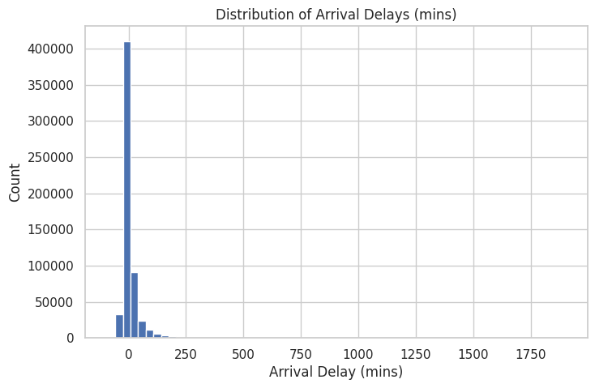

```python
# Visualize the distribution of arrival delays to assess skewness,
# outliers, and the overall spread of delay values.

plot_hist(flights, 'ArrDelay',
          bins=60,
          title='Distribution of Arrival Delays (mins)',
          xlabel='Arrival Delay (mins)')
```

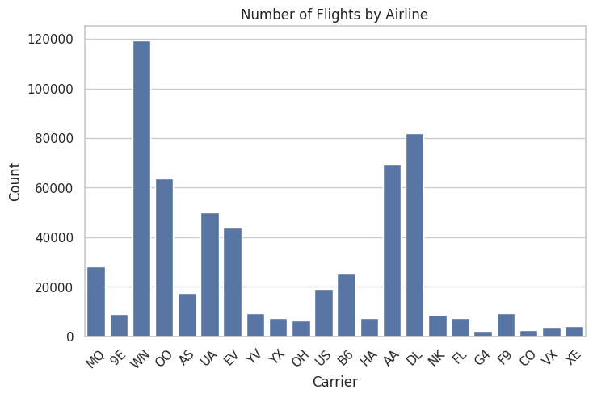

```python
# Display the number of flights per airline to identify
# the most active carriers and assess data imbalance.

plot_count(flights, 'Reporting_Airline',
           title='Number of Flights by Airline',
           xlabel='Carrier',
           rotation=45)
```

### Discuss the distribution(s) of your variable(s) of interest. Were there any unusual points? Did you need to perform any transformations?

The distribution of arrival delays and departure delays is strongly right-skewed, with most flights arriving close to on time or slightly early, and a smaller number of flights experiencing very large delays. Negative delay values indicate early arrivals or departures and cluster near zero, while extreme positive values extend far into the right tail.

Several unusual points (outliers) were observed, including flights delayed by several hours. These extreme delays are rare but meaningful and likely represent disruptions such as weather events, mechanical issues, or air traffic control constraints. No transformations were applied at this stage, as preserving the full range of delays helps illustrate the true variability in flight performance and supports later comparisons.

### Of the features you investigated, were there any unusual distributions? Did you perform any operations on the data to tidy, adjust, or change the form of the data? If so, why did you do this?

Some additional features showed notable patterns. The number of flights by airline was unevenly distributed, with a small number of carriers accounting for a large share of total flights. Flight distance also exhibited right-skewness, with many short- and medium-haul flights and relatively few long-distance routes.

Missing values were primarily concentrated in delay and airtime fields and corresponded mostly to cancelled or diverted flights. These values were retained rather than removed during univariate exploration to avoid biasing the dataset and to preserve contextual information for later analyses. No major structural changes or transformations were required at this stage, as the data was already suitable for exploratory visualization.

## Bivariate Exploration

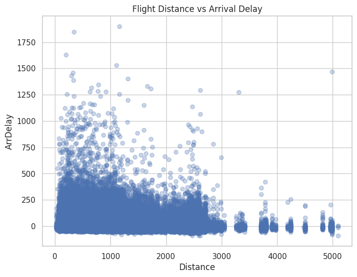

```python
# Explore the relationship between flight distance and arrival delay
# to assess whether longer flights tend to experience greater delays.

plot_scatter(
    flights,
    x="Distance",
    y="ArrDelay",
    title="Flight Distance vs Arrival Delay"
)
```

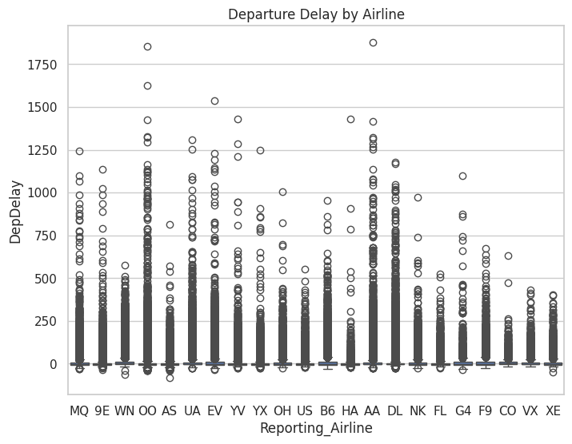

```python
# Compare departure delay distributions across airlines
# to evaluate differences in operational performance.

plot_box(
    flights,
    x="Reporting_Airline",
    y="DepDelay",
    title="Departure Delay by Airline"
)
```

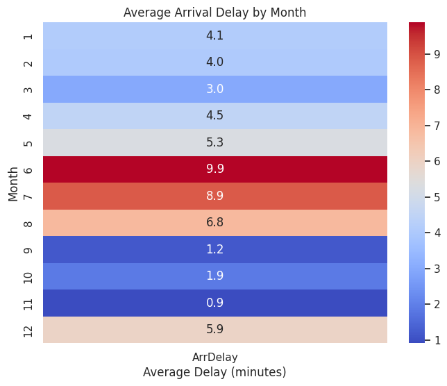

```python
# Examine seasonal patterns in arrival delays by calculating
# the average delay for each month across all flights.

plot_pivot_heatmap(
    flights,
    values="ArrDelay",
    index="Month",
    aggfunc="mean",
    title="Average Arrival Delay by Month",
    xlabel="Average Delay (minutes)",
    ylabel="Month"
)
```

### Talk about some of the relationships you observed in this part of the investigation. How did the feature(s) of interest vary with other features in the dataset?

Several meaningful relationships emerged between arrival delay (the main feature of interest) and other variables. A positive relationship was observed between departure delay and arrival delay, indicating that flights departing late tend to arrive late as well. While some flights were able to recover time during flight, large departure delays generally propagated through to arrival.

### Did you observe any interesting relationships between the other features (not the main feature(s) of interest)?

Seasonal effects were also hinted at when examining delay patterns by month, with certain months exhibiting higher average delays, likely due to weather conditions or peak travel demand. These relationships motivated further multivariate exploration to examine how multiple factors interact to influence flight delays.

## Multivariate Exploration

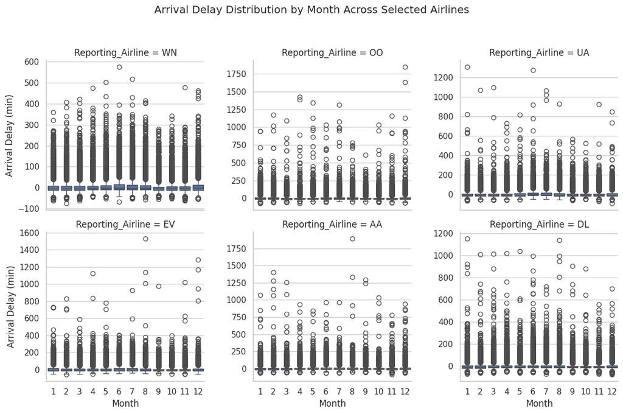

```python
# Compare monthly arrival delay distributions across major airlines
# using faceted boxplots to identify airline-specific seasonal trends.

facet_boxplot(
    flights,
    facet_col="Reporting_Airline",
    x="Month",
    y="ArrDelay",
    top_n=6,
    order=list(range(1, 13)),
    col_wrap=3,
    height=4,
    sharey=False,
    title="Arrival Delay Distribution by Month Across Selected Airlines",
    xlabel="Month",
    ylabel="Arrival Delay (min)",
    dropna_cols=["ArrDelay", "Month", "Reporting_Airline"]
)
```

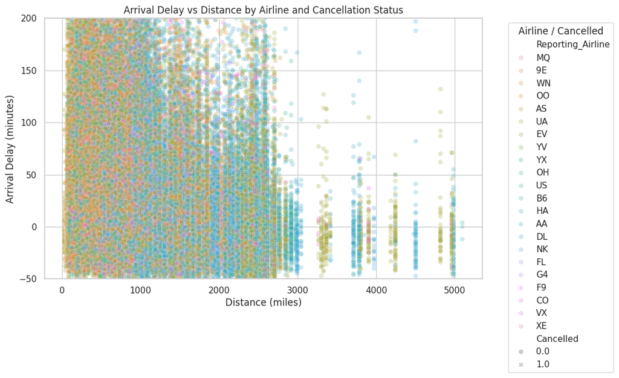

```python
# Multivariate scatter plot examining how arrival delay varies with flight distance,
# while encoding airline by color and cancellation status by marker style.
# This allows us to observe interactions between distance, airline behavior,
# and whether cancellations are associated with extreme delays.

plt.figure(figsize=(10, 6))

sns.scatterplot(
    data=flights,
    x="Distance",
    y="ArrDelay",
    hue="Reporting_Airline",   # Color encodes airline
    style="Cancelled",         # Marker shape encodes cancellation status
    alpha=0.25
)

plt.title("Arrival Delay vs Distance by Airline and Cancellation Status")
plt.xlabel("Distance (miles)")
plt.ylabel("Arrival Delay (minutes)")
plt.ylim(-50, 200)

plt.legend(
    title="Airline / Cancelled",
    bbox_to_anchor=(1.05, 1),
    loc="upper left"
)

plt.show()
```

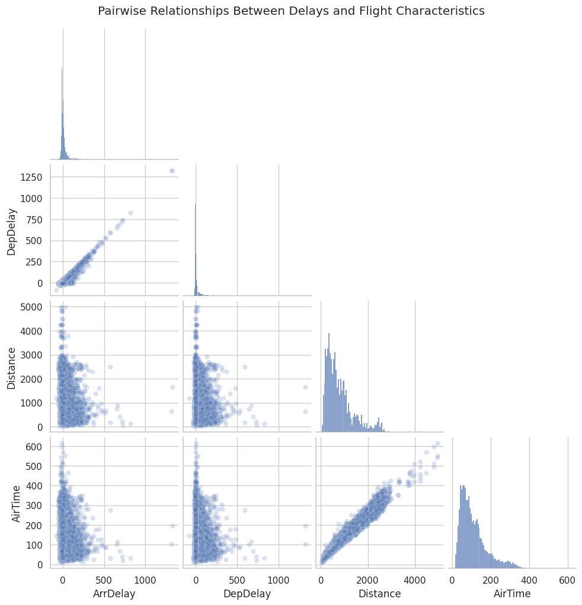

```python
# Multivariate plot matrix (pair plot) to examine pairwise relationships
# between arrival delay, departure delay, distance, and air time.
# A random sample is used to reduce overplotting and improve rendering performance.

sample = flights.sample(20000, random_state=1)  # reduce rendering time

sns.pairplot(
    sample[['ArrDelay', 'DepDelay', 'Distance', 'AirTime']],
    corner=True,
    plot_kws={'alpha': 0.2}
)

plt.suptitle(
    "Pairwise Relationships Between Delays and Flight Characteristics",
    y=1.02
)

plt.show()
```

### Talk about some of the relationships you observed in this part of the investigation. Were there features that strengthened each other in terms of looking at your feature(s) of interest?

The multivariate analysis revealed that arrival delay is influenced by the interaction of several factors rather than any single variable alone. When examining arrival delay across month and airline using facet plots, seasonal patterns became clearer. Certain airlines experienced consistently higher delays during specific months, suggesting that the combined effects of carrier operations and seasonal demand or weather conditions amplify delay outcomes.

These interactions demonstrate that delay behavior becomes more interpretable when multiple features are considered together, particularly airline, time period, and departure performance.

### Were there any interesting or surprising interactions between features?

Overall, the multivariate exploration showed that flight delays are the result of complex interactions between operational, temporal, and airline-specific factors, reinforcing the importance of analyzing multiple variables simultaneously rather than in isolation.

## Conclusions

In this investigation, I explored U.S. flight performance data from the most recent ten years to better understand the factors that contribute to arrival delays. The primary focus was on arrival delay, with supporting features including departure delay, airline, month, flight distance, and cancellation status.

### Reflection on the Exploration Process

The structured progression from univariate to multivariate exploration was essential in uncovering meaningful insights. Initial univariate plots helped identify skewed distributions and potential outliers, while bivariate analysis revealed clear relationships between delay variables. Multivariate visualizations were especially valuable for understanding how airline, time, and operational factors interact to influence delays.

Using functions to standardize visualizations improved code readability and reduced repetition, allowing for more efficient exploration. Sampling was necessary for computational efficiency, particularly for multivariate plots, without sacrificing interpretability.

Overall, this exploratory analysis demonstrates that flight delays are the result of interacting operational and temporal factors, rather than any single variable, and highlights the importance of visual analysis in understanding complex real-world datasets.

```python
# Save cleaned 10-year flights dataset for reuse in Part II
flights.to_csv("flights_clean_10yr.csv", index=False)

print("Clean dataset saved as flights_clean_10yr.csv")
```

```
Clean dataset saved as flights_clean_10yr.csv
```